# Class 4 Laboratory

## 4.1 Kriging Maximum Temperature

In this Lab we go through the process of carrying out spatio-temporal universal kriging using the semivariogram with the package `gstat`. We focus on the maximum temperature data in the NOAA data set (Tmax) in July 1993.

```r
library("sp")
library("spacetime")
library("gstat")
library("RColorBrewer")
library("STRbook")
library("tidyverse")
```

For S-T kriging of the maximum-temperature data set in July 1993, we need to fit a parametric function to the empirical semivariogram `vv` computed in Lab 2.3. The code is reproduced below for completeness.

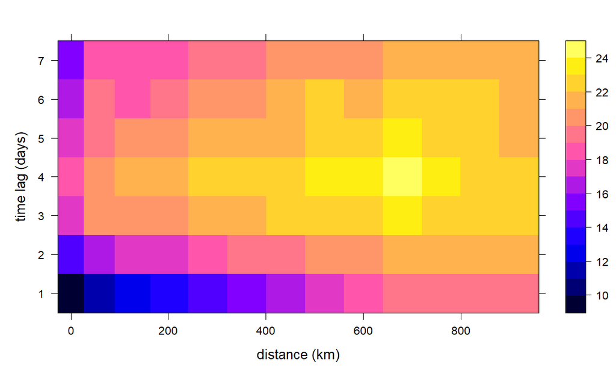

```r
data("STObj3", package = "STRbook")
STObj4 <- STObj3[, "1993-07-01::1993-07-31"]

vv <- variogram(object = z ~ 1 + lat, # fixed effect component
                data = STObj4, # July data
                width = 80, # spatial bin (80 km)
                cutoff = 1000, # consider pts < 1000 km apart
                tlags = 1:7) # 0 days to 6 days
plot(vv)
```

The first semivariogram we consider here corresponds to the spatio-temporal separable covariance function:

$$C_{\text{sep}}(h,\tau)=C_s(h)C_t(\tau)$$
Its variogram is given by

$$γ_{\text{sep}}(h,\tau) = \text{sil} \cdot \left( \bar{γ}_s(h)
+\bar{γ}_t(\tau)-\bar{γ}_s(h) \bar{γ}_t(\tau))\right)$$
where $\bar{γ}_t(\tau)$ and $\bar{γ}_s(h)$ are standardized semivariograms with separate nugget effects and joint sill of 1.

A spatio-temporal semivariogram is constructed with **gstat** using the function `vgmST`. The argument `stModel = "separable"` is used to define a separable model, while the function `vgm` is used to construct the individual semivariograms (one for space and one for time).

Several arguments can be passed to `vgm. The first four, which we use below, correspond to the partial sill, the model type, the range, and the nugget, respectively. The argument`sill`that is supplied to`vgmST`defines the joint spatio-temporal`sill`. The numbers used in their definition are initial values supplied to the optimization routine used for fitting in the function`fit.StVariogram`, which fits`sepVgm`to`vv`.

These initial values should be reasonable – for example, the length scale $φ$ can be set to a value that spans $10%$ of the spatial/temporal domain, and the variances/sills can be set such that they have similar orders of magnitude to the total variance of the measurements.

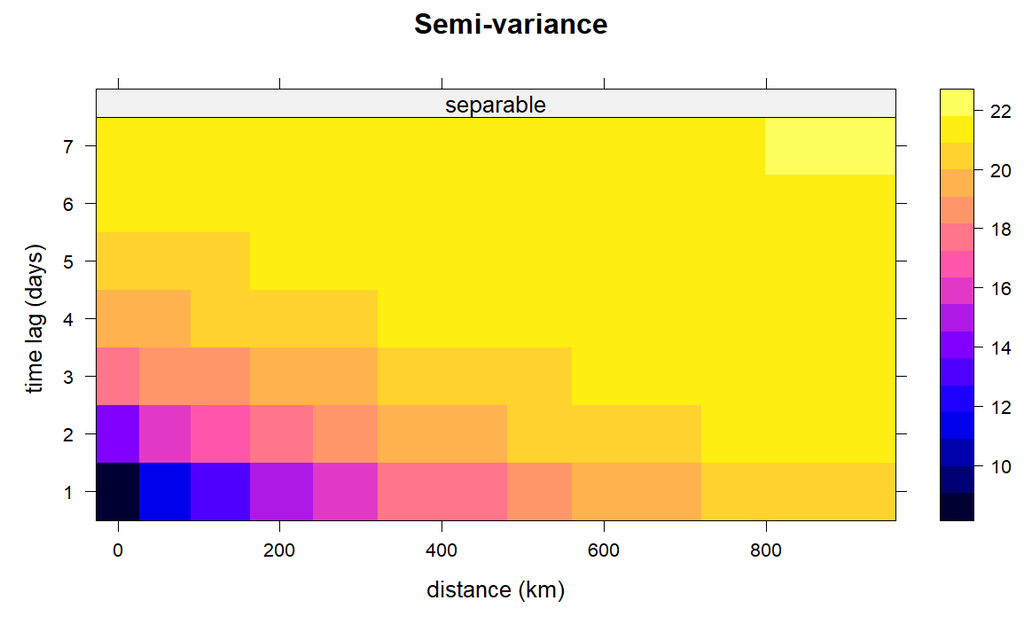

```r
sepVgm <- vgmST(stModel = "separable",
                space = vgm(10, "Exp", 400, nugget = 0.1),
                time = vgm(10, "Exp", 1, nugget = 0.1),
                sill = 20)
sepVgm <- fit.StVariogram(vv, sepVgm)

plot(vv, sepVgm, main = "Semi-variance")
```

Next, we use the fitted S-T covariance models for prediction using S-T kriging, in this case universal S-T kriging since we are treating the latitude coordinate as a covariate. First, we need to create a space-time prediction grid. For our spatial grid, we consider 20 spatial locations between 100◦W and 80◦W, and 20 spatial locations between 32◦N and 46◦N. In the code below, when converting to SpatialPoints, we ensure that the coordinate reference system (CRS) of the prediction grid is the same as that of the observations.

```r
spat_pred_grid <- expand.grid(
  lon = seq(-100, -80, length = 20),
  lat = seq(32, 46, length = 20)) %>%
  SpatialPoints(proj4string = CRS(proj4string(STObj3)))
gridded(spat_pred_grid) <- TRUE
```

For our temporal grid, we consider six equally spaced days in July 1993.

```r
temp_pred_grid <- as.Date("1993-07-01") + seq(3, 28, length = 6)
```

We can then combine `spat_pred_grid` and `temp_pred_grid` to construct an STF object for our space-time prediction grid.

```r
DE_pred <- STF(sp = spat_pred_grid, # spatial part
               time = temp_pred_grid) # temporal part
```

Since there are missing observations in STObj4, we first need to cast STObj4 into either an STSDF or an STIDF, and remove the data recording missing observations. For simplicity here, we consider the STIDF (considering STSDF would be around twice as fast). Also, in order to show the capability of S-T kriging to predict across time, we omitted data on 14 July 1993 from the data set.

```r
STObj5 <- as(STObj4[, -14], "STIDF") # convert to STIDF
STObj5 <- subset(STObj5, !is.na(STObj5$z)) # remove missing data
```

Now we can call krigeST using STObj5 as our data.

```r
pred_kriged <- krigeST(z ~ 1 + lat, # latitude trend
                       data = STObj5, # data set w/o 14 July
                       newdata = DE_pred, # prediction grid
                       modelList = sepVgm, # semivariogram
                       computeVar = TRUE) # compute variances
```

To plot the predictions and accompanying prediction standard errors, it is straightforward to use the function `stplot`. First, we define our color palette using the function `brewer.pal` and the function `colorRampPalette`.

```r
color_pal <- rev(colorRampPalette(brewer.pal(11, "Spectral"))(16))
```

Second, we call the `stplot` function with the object containing the results.

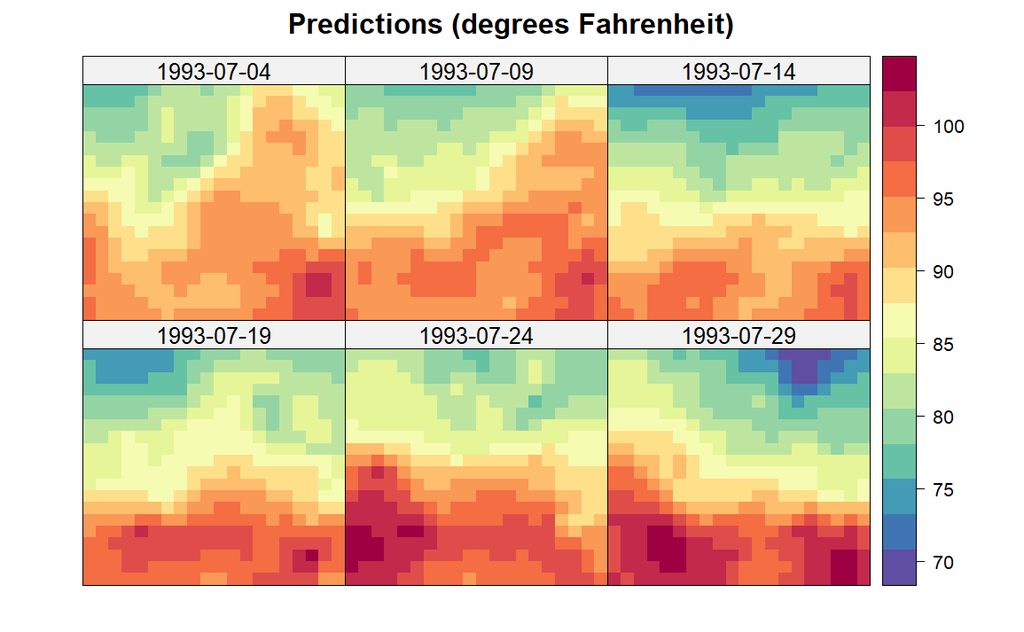

```r
stplot(pred_kriged,
       main = "Predictions (degrees Fahrenheit)",
       layout = c(3, 2),
       col.regions = color_pal)
```

Spatio-temporal kriging as shown in this Lab is relatively quick and easy to implement for small data sets, but it starts to become prohibitive as data sets grow in size, unless some approximation is used. For example, the function krigeST allows one to use the argument nmax to determine the maximum number of observations to use when doing prediction. The predictor is no longer optimal, but it is close enough to the optimal predictor in many cases of practical interest.

## Kriging Daily Mean $PM_10$ Concentration

The data set used is taken from AirBase2, the air quality data base for Europe provided by the European Environmental Agency (EEA). We focus on a single air quality indicator, particulate matter with a diameter less than 10 mm, measured at rural background stations for 2005 ($PM_{10}$).

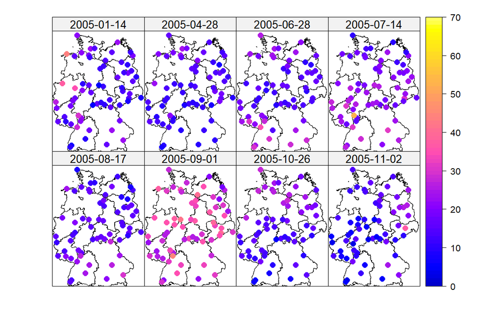

```r
library(sp)
library(spacetime)
library(gstat)
#library(rgdal)

# load data from package gstat
data(DE_RB_2005, package = "gstat")

paper <- FALSE
set.seed(123)
smplDays <- sort(sample(365,8))

# load German boundaries
data(air)
DE_NUTS1 <- spTransform(DE_NUTS1, CRS("+init=epsg:32632"))

stplot(as(DE_RB_2005[,smplDays],"STFDF"),
       col.regions=bpy.colors(120)[-(1:20)],
       sp.layout = list("sp.polygons", DE_NUTS1), scales=list(draw=F),
       key.space="right", colorkey=T, cuts=0:70,
       main=NULL)
```

In order to fit a spatio-temporal model to the air quality data set, the empirical variogram surface is computed and used as input for the fitting routines of the different models. The empirical variogram is based on spatio-temporal bins that span regularly over space and time.

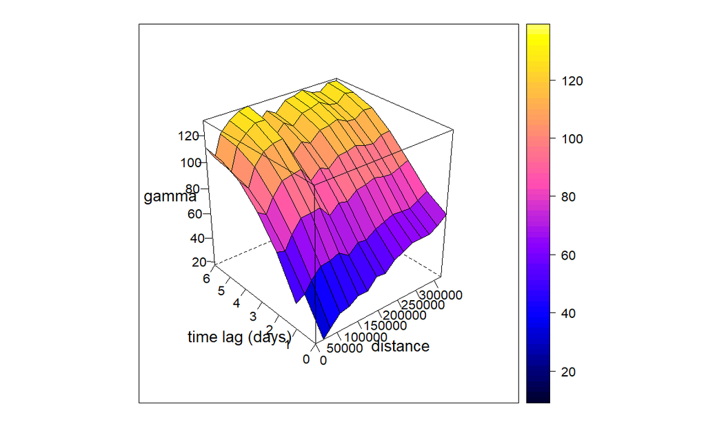

```r
# calculate the empirical variogram
empVgm <- variogramST(PM10~1, DE_RB_2005, tlags=0:6)
plot(empVgm, wireframe=T, scales=list(arrows=F))
```

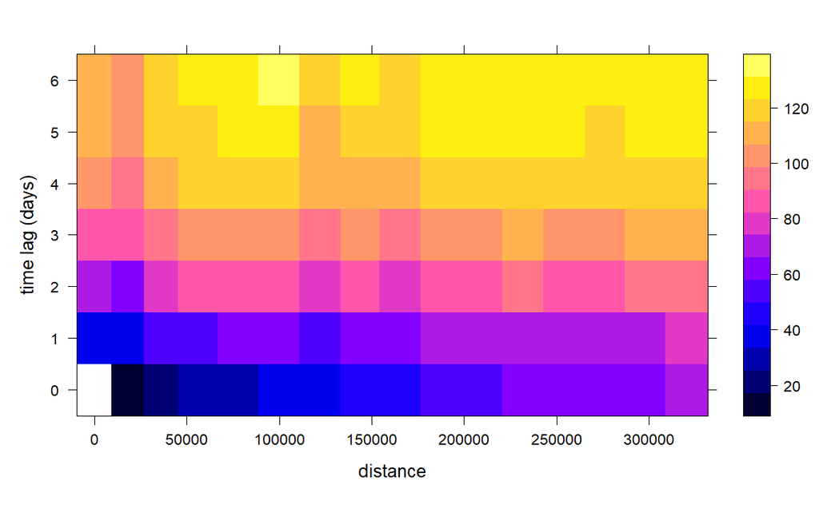

```r
plot(empVgm)
```

```r
# rescale empVgm and linStAni to km for estimation
empVgm$dist  <- empVgm$dist/1000
empVgm$avgDist  <- empVgm$avgDist/1000
empVgm$spacelag <- empVgm$spacelag/1000
```

```r
# fit of theoretical spatio-temporal models #
#############################################
linStAni <- estiStAni(empVgm, c(50,200))

# separable
separableModel <- vgmST("separable",
                        space=vgm(0.9,"Exp", 200, 0.1),
                        time =vgm(0.9,"Sph", 3.5, 0.1),
                        sill=120)
fitSepModel <- fit.StVariogram(empVgm, separableModel, fit.method = 7,
                               stAni = linStAni, method = "L-BFGS-B",
                               control = list(parscale=c(100,1,10,1,100)),
                               lower = c(10,0,.1,0,0.1),
                               upper = c(2000,1,12,1,200))
attr(fitSepModel, "optim.output")$value
```

```
[1] 6.817119
```

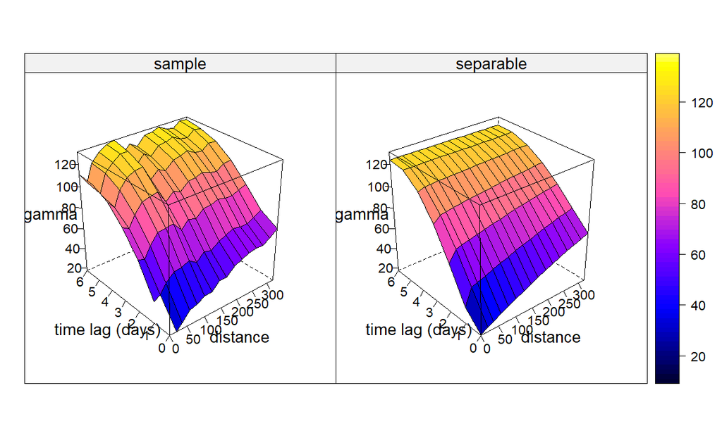

```r
# Exp+Exp: 9.87, Exp+Sph: 6.82, Sph+Exp: 10.42, Sph+Sph: 7.50

plot(empVgm, fitSepModel, wireframe=T, all=T, scales=list(arrows=F))
```

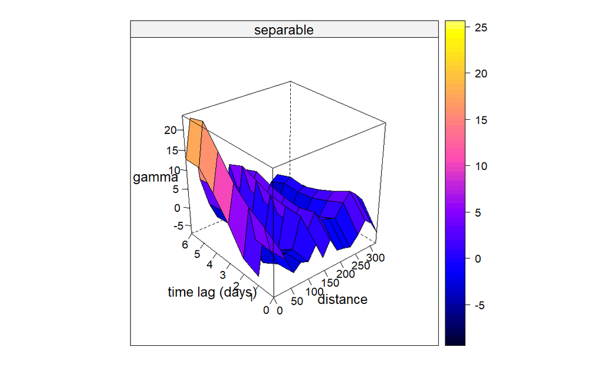

```r
plot(empVgm, fitSepModel, wireframe=T, all=T, scales=list(arrows=F), diff=TRUE)
```

```r
# libraries
library(sp)
library(spacetime)
library(gstat)
#library(rgdal)

# animate <- FALSE

# interpolation
# build a grid over Germany
gridDE <- SpatialGrid(GridTopology(DE_RB_2005@sp@bbox[,1]%/%10000*10000, c(10000,10000),
                                   cells.dim=ceiling(apply(DE_RB_2005@sp@bbox,1,diff)/10000)))
proj4string(gridDE) <- CRS("+init=epsg:32632")
fullgrid(gridDE) <- F

ind <- over(gridDE, as(DE_NUTS1,"SpatialPolygons"))
gridDE <- gridDE[!is.na(ind)]

# back scale vgms:
fitSepModel$space$range <- fitSepModel$space$range*1000

DE_pred <- STF(gridDE, DE_RB_2005@time[smplDays])

tIDS <- unique(pmax(1,pmin(as.numeric(outer(-5:5, smplDays, "+")), 365)))


# Check CRS of the prediction grid (assuming it's a Spatial or STSDF object)
crs_new <- proj4string(DE_pred)
print(paste("CRS of DE_pred:", crs_new))
```

```
[1] "CRS of DE_pred: +proj=utm +zone=32 +datum=WGS84 +units=m +no_defs"
```

```r
DE_RB_2005_transformed <- DE_RB_2005
DE_RB_2005_transformed@sp <- spTransform(DE_RB_2005@sp, CRS(crs_new))

sepPred <- krigeST(PM10 ~ 1,
                   data = DE_RB_2005_transformed[, tIDS],
                   newdata = DE_pred,
                   model = fitSepModel,
                   nmax = 50,
                   stAni = fitMetricModel$stAni / 24 / 3600)
```

[output not shown]

[output cut: 9 more lines]

[output not shown]

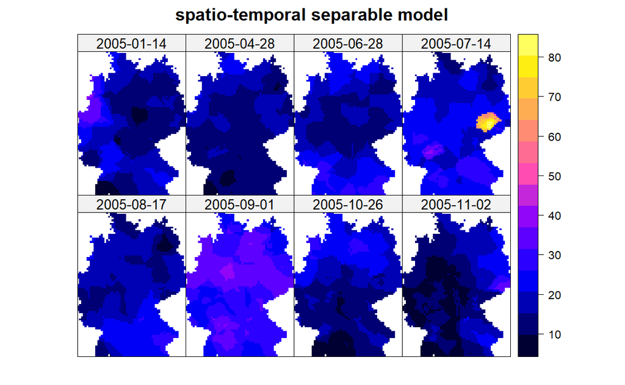

```r
stplot(sepPred, col.regions=bpy.colors(), scales=list(draw=F),
         main="spatio-temporal separable model")
```

## 4.3 Implementing an IDE Model in One-Dimensional Space

Consider the dynamic model,

$$Y_t(s) = \int_{D_s}m(s,x)Y_{t-1}(x)dx + \eta_t(s),$$
where $Y_t(\dot)$ is the spatio-temporal process at time $t$; and $\eta_t(\dot)$ is a spatial process, independent of $Y_t(\dot)$, with covariance function which we shall assume is known.

We first include some packages.

```r
library("tidyverse")
library("STRbook")
library("MASS") # mvrnorm
library("data.table") # combine list Y[[i]]
library("IDE") # fit and predict IDE models
library("FRK") # construct basis functions
library("sp")
library("spacetime")
#install.packages('parallelly')
set.seed(1)
```

### 4.3.1 Constructing the Process Grid and Kernel

We start off by constructing a discretization of the one-dimensional spatial domain $D_s =[0,1]$. We shall use this discretization, containing cells of width $\Delta_s$, for both approximate integrations as well as visualizations. We call this our **spatial grid**.

```r
ds <- 0.01
s_grid <- seq(0, 1, by = ds)
N <- length(s_grid)
```

Our space-time grid is formed by calling `expand.grid` with `s_grid` and our temporal domain, which we define as the set of integers spanning $0$ up to $T = 200$.

```r
nT <- 201
t_grid <- 0:(nT-1)
st_grid <- expand.grid(s = s_grid, t = t_grid)
```

The transition kernel $m(s, x)$ is a bivariate function on our spatial grid. It is defined below to be a Gaussian kernel, where $\theta_{p,1}, \theta_{p,2}, \theta_{p,3}$ are the amplitude, the scale, and the shift of the kernel, respectively.

$$m(s,x)=\theta_{p,1}
\exp\left(-\frac{1}{\theta_{p,2}}(x-\theta_{p,3}-s)^2\right)$$

```r
m <- function(s, x, thetap) {
  gamma <- thetap[1] # amplitude
  l <- thetap[2] # length scale
  offset <- thetap[3] # offset
  D <- outer(s + offset, x, '-') # displacements
  gamma * exp(-D^2/l) # kernel eval.
}
```

We can now visualize some kernels by seeing how the process at $s = 0.5$ depends on $x$.

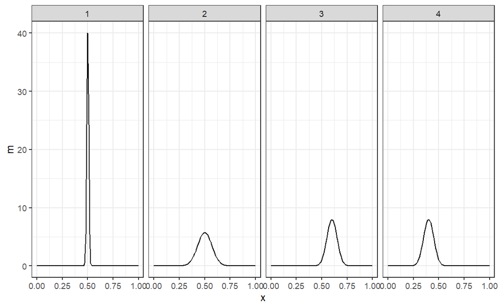

```r
thetap <- list()
thetap[[1]] <- c(40, 0.0002, 0)
thetap[[2]] <- c(5.75, 0.01, 0)
thetap[[3]] <- c(8, 0.005, 0.1)
thetap[[4]] <- c(8, 0.005, -0.1)

df <- data.frame(x=numeric(),m=numeric(),kernel=integer())

for(i in 1:4){
  m_x_0.5 <- m(s = 0.5, x = s_grid,              # construct kernel
               thetap = thetap[[i]]) %>%         # at s = 0.5
    as.numeric()                                 # convert to numeric

  df <- rbind(df, data.frame(x = s_grid, m = m_x_0.5, kernel=i)) # allocate to df

}

ggplot(df) + geom_line(aes(x, m)) + facet_grid(. ~ kernel) + theme_bw() # plot
```

The last term we need to define is $\eta_t(\dot)$. Here, we define it as a spatial process with an exponential covariance function with range parameter $0.1$ and variance $0.1$. The covariance matrix at each time point is then

```r
Sigma_eta <- 0.1 * exp( -abs(outer(s_grid, s_grid, '-') / 0.1))
#
# L <- t(chol(Sigma_eta)) # chol() returns upper Cholesky factor
# sim <- L %*% rnorm(nrow(Sigma_eta)) # simulate
# hist(sim)
```

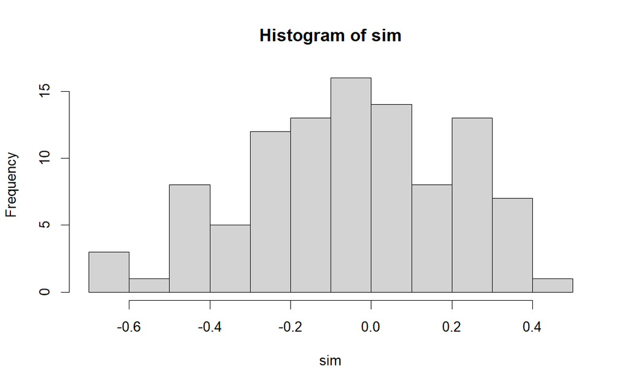

```r
sim <- mvrnorm(n=1, mu=rep(0,nrow(Sigma_eta)), Sigma=Sigma_eta)
hist(sim)
```

### 4.3.2 Simulating from the IDE

We shall carry out four simulations, one for each kernel constructed above, and store the simulations in a list of four data frames, one for each simulation.

```r
Y <- list()
```

For each simulation setting (which we iterate using the index `i`), we simulate the time points (which we iterate using `j`) to obtain the process. The “nested for `loop`” below accomplishes this. In the outer loop, the kernel is constructed and the process is initialized to zero. In the inner loop, the integration is approximated using a Riemann sum,

$$\int_{D_s}m(s,x)Y_{t-1}(x)dx \approx \sum_i m(s,x_i)
Y_{t-1}(x_i)\Delta_s$$

where we recall that we have set $\Delta_s = 0.01$. Next, at every time point $\eta_t(s)$ is simulated on the grid and added to the sum (an approximation of the integral) above.

```r
for(i in 1:4) { # for each kernel
  M <- m(s_grid, s_grid, thetap[[i]]) # construct kernel
  Y[[i]] <- data.frame(s = s_grid, # init. data frame with s
                       t = 0, # init. time point 0, and
                       Y = 0) # init. proc. value = 0
  for(j in t_grid[-1]) { # for each time point
    prev_Y <- filter(Y[[i]], # get Y at t - 1
                     t == j - 1)$Y

    # eta <- L %*% rnorm(N) # simulate eta
    eta <- mvrnorm(n=1, mu=rep(0,N), Sigma=Sigma_eta) # simulate eta
    new_Y <- (M %*% prev_Y * ds + eta) %>%
      as.numeric() # Euler approximation
    Y[[i]] <- rbind(Y[[i]], # update data frame
                    data.frame(s = s_grid,
                               t = j,
                               Y = new_Y))
  }
}
```

The code given below constructs the Hovmöller plot.

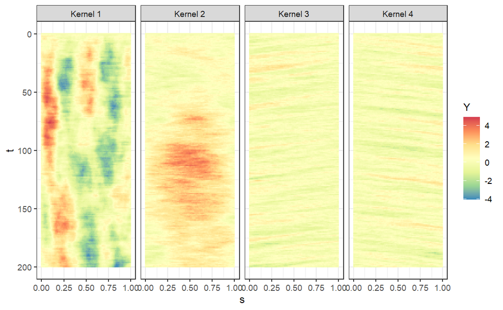

```r
Y_all <- rbindlist(Y)
Y_all$kernel = rep(c("Kernel 1","Kernel 2","Kernel 3","Kernel 4"), each=nrow(Y[[1]]))

ggplot(Y_all) + geom_tile(aes(s, t, fill = Y)) +
  scale_y_reverse() + theme_bw() +
  facet_grid(. ~ kernel) +
  fill_scale(name = "Y")
```

### 4.3.3 Simulation Observations

Now we want to simulate noisy observations from one of the process models.

We need an incidence matrix that picks out the process value that has been observed. This incidence matrix is simply composed of several rows, one for each observation, with zeros everywhere except for the entry corresponding to the process value that has been observed.

Suppose that at each time point we observe the process at 50 locations which, for convenience, are a subset of `s_grid`.

```r
nobs <- 50
sobs <- sample(s_grid, nobs)

Ht <- matrix(0, nobs, N) # construct empty matrix
for(i in 1:nobs) { # for each obs
  idx <- which(sobs[i] == s_grid) # find the element to set to 1
  Ht[i, idx] <- 1 # set to 1
}
```

We can repeat this procedure for every time point to simulate our data. At time $t$, the data are given by $Z_t = H_tY_t + ε_t$, where $Y_t$ is the latent process on the grid at time $t$, and $ε_t$ is independent of $Y_t$ and represents a Gaussian random vector whose entries are iid with mean zero and variance $σ^2_\epsilon$ . Assume $σ^2_\epsilon=1$ and that $H_t$ is the same for each $t$. Then observations are simulated using the following for `loop`.

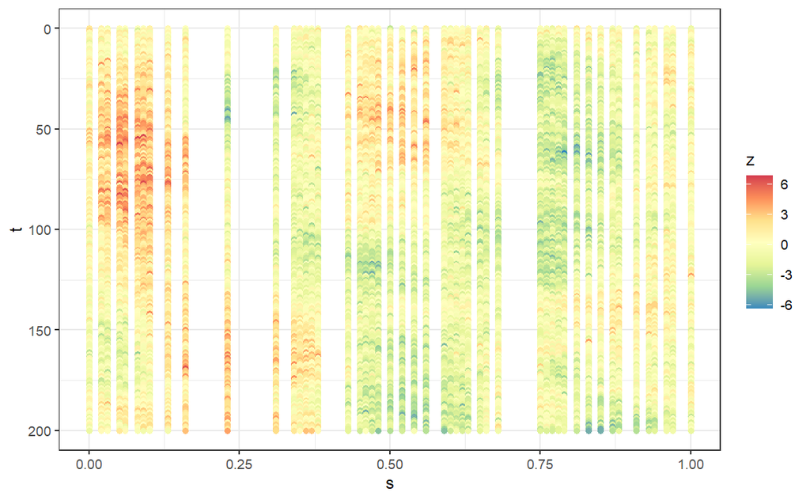

```r
z_df <- data.frame() # init data frame
for(j in 0:(nT-1)) { # for each time point
  Yt <- filter(Y[[1]], t == j)$Y # get the simulated process
  zt <- Ht %*% Yt + rnorm(nobs) # map to obs and add noise
  z_df <- rbind(z_df, # update data frame
                data.frame(s = sobs, t = j, z = zt))
}

ggplot(z_df) + geom_point(aes(s, t, colour = z)) +
  col_scale(name = "z") + scale_y_reverse() + theme_bw()
```

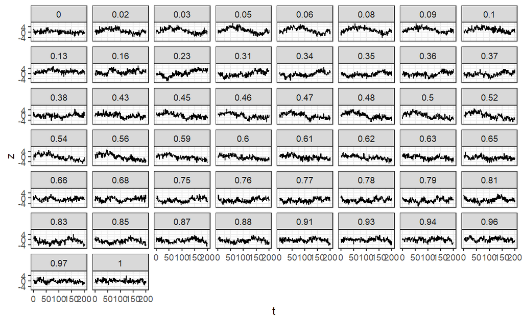

```r
ggplot(z_df) + geom_line(aes(x=t,y=z)) + facet_wrap(.~s) + theme_bw()
```

Note that the observations are noisy and reveal sizeable gaps. Our goal is to fill in these gaps by estimating all the parameters in the IDE from the data and then predicting at unobserved locations.

## 4.4 The Sydney Radar Data Set

Analysis of the Sydney radar data set proceeds in much the same way as in the simulation examples. We first load the Sydney radar data set as an `STIDF` object.

```r
data("radar_STIDF", package = "STRbook")
```

We assume the following model:

$$Z_t(s) = \beta_0 +Y_t(s) + \epsilon_t(s),$$
where $Y_t(s) = \int_{D_s}m(s,x)Y_{t-1}(x)dx + \eta_t(s)$.

```r
IDEmodel <- IDE(f = z ~ 1,
                data = radar_STIDF,
                dt = as.difftime(10, units = "mins"),
                forecast = 2,
                hindcast = 2)
```

The added arguments `hindcast` and `forecast` indicate how many time intervals into the past, and how many into the future that we wish to predict for periods preceeding the training period (`hindcast`) and periods following the training period (`forecast`), respectively.

```r
#fit_results_radar <- fit.IDE(IDEmodel, parallelType = 1)
data("IDE_Radar_results", package = "STRbook")
```

The fitted kernel can be visualized as it was before:

```
Kernel is spatially invariant, plotting it centred on the origin.
```

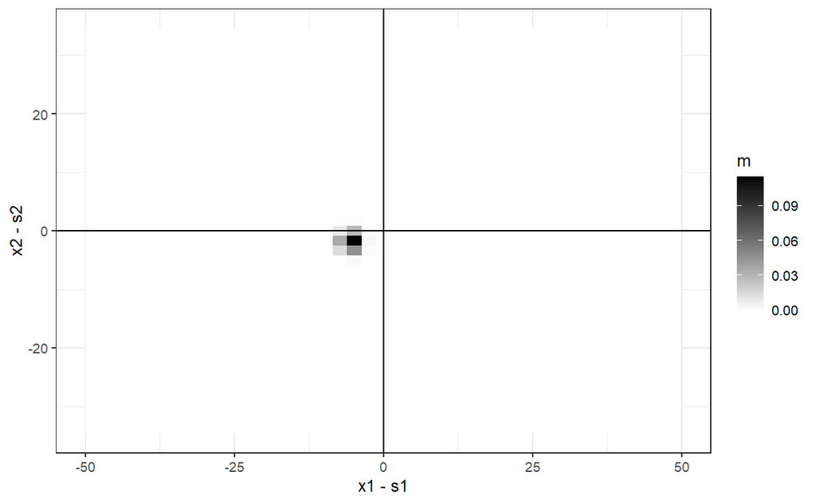

```r
show_kernel(fit_results_radar$IDEmodel)
```

The kernel is again clearly shifted off-center and suggestive of transport in a predominantly easterly (and slightly northerly) direction. This is corroborated by visual inspection of the data. The estimated shift parameters are as follows.

```r
shift_pars <- (fit_results_radar$IDEmodel$get("k") %>% unlist())[3:4]
print(shift_pars)
```

```
     par3      par4
-5.488385 -1.860784
```

The magnitude of the estimated shift vector is hence indicative of a transport of $\sqrt{(5.5)^2 + (1.9)^2} = 5.82$ km per 10-minute period, or $34.91$ km per hour.

When calling the function `IDE`, we set up the object to be able to forecast 20 minutes into the future and hindcast 20 minutes into the past. These forecasts and hindcasts will be in the object returned from `predict`.

```r
ST_grid_df <- predict(fit_results_radar$IDEmodel)
```

The code given below plots the data as well as the smoothed fields containing the hindcasts, the predictions, and the forecasts.

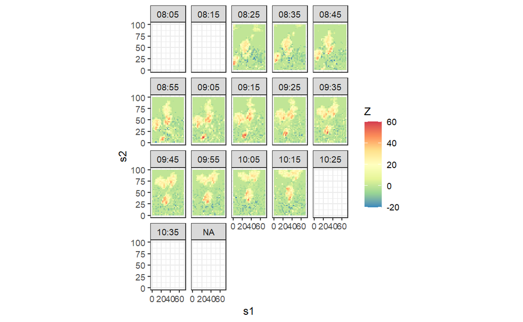

```r
radar_df$time <- format(radar_df$t, "%H:%M")
ST_grid_df$time <- format(ST_grid_df$t, "%H:%M")

## Add time records with missing data
radar_df <- rbind(radar_df,
                  data.frame(s1=rep(NA,4),s2=rep(NA,4),t=rep(NA,4),z=rep(NA,4),
                             time = c("08:05", "08:15", "10:25", "10:35")))

## Plot of data, with color scale capped to (-20, 60)
gobs <- ggplot(radar_df) +
  geom_tile(aes(s1, s2, fill = pmin(pmax(z, -20), 60))) +
  fill_scale(limits = c(-20, 60), name = "Z") +
  facet_wrap(~time) + coord_fixed() + theme_bw()

## Plot of predictions with color scale forced to (-20, 60)
gpred <- ggplot(ST_grid_df) +
  geom_tile(aes(s1, s2, fill = Ypred)) +
  facet_wrap(~time) + coord_fixed() + theme_bw() +
  fill_scale(limits = c(-20, 60), name = "Ypred")

gobs
```

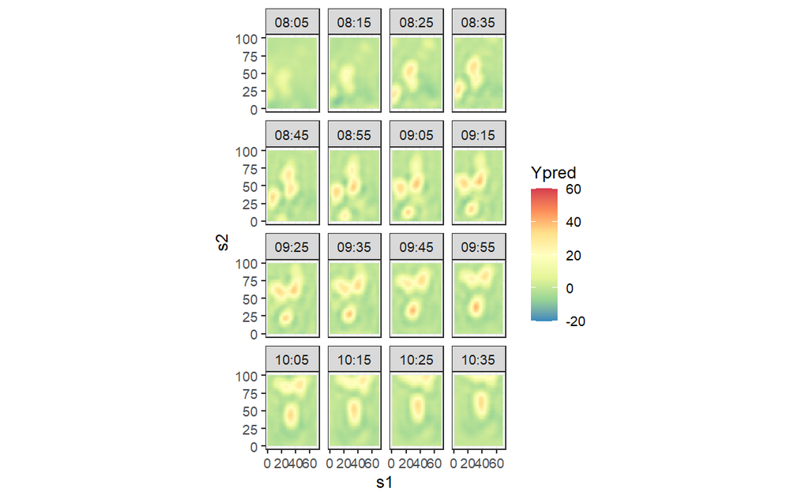

```r
gpred
```